# U.S. Small Business Administration Loans

Lab Assignment One: Exploring Table Data

*Mark Brubaker*

## Business Understanding

The Small Business Administration (SBA) was created in 1953 to make loans more accessible to small businesses and less risky for banks. Small business fail at a high rate making any loan they take out inherently risky. In order to mitigate this risk the SBA will guarantee a portion of the loan. This means that if the business defaults on the loan the SBA will pay the bank the guaranteed amount. This allows banks to make loans to small businesses that they would not otherwise make. These loans are crucial for many small businesses to get started and grow.

Small businesses are a major part of the U.S. economy. In 2015 they employed 58.9 million people and accounted for 99.7% of all U.S. businesses. Small businesses are also responsible for 54.2% of all U.S. sales. Investing in these businesses is a good way to stimulate the economy and create jobs. The SBA loans are a major part of this investment.

It's clear that striking a balance between incentivising small businesses and mitigating risk for banks investing them is very important. By analyzing historical data on SBA loans that have already been accepted and either paid off or defaulted we can get a better understanding of how to strike this balance. There are many factors that can be used to predict the likelihood of a loan defaulting and by exploring how each of these these factors impact the chance of a loan defaulting we can better understand which loans should be accepted and which should be rejected.

Both the SBA and a bank need to accept a loan in order for a small business to receive funding. A model predicting the likeliness of default would be useful for both parties even though they have different goals. The SBA wants to give opportunities to as many small businesses as possible in order to create jobs and stimulate the economy. A bank wants to accept as many of these loans as they can assuming the risk is low enough. An accurate model predicting the likeliness of default would allow both parties to make better decisions.

## Measure of Success

A strict measure of success for a model would be its ability to accurately predict if a loan would default or not. However a model does not need to be perfect to still be useful. For banks, the model would only need to be accurate enough so that the successfully paid loans could offset the losses from bad predictions. Given that a large portion of every loan is guaranteed by the SBA, this margin for error is likely quite large. For the SBA, the model would need to be accurate enough to ensure that the loans they accept are likely to be paid off. The risk is just the cost of investing in small businesses and the potential reward of jobs and economic growth is easy to justify as worth it. Obviously, for both parties every bit more accurate the model is the less money is lost.

## Data Description

Because of the number of attributes, only the most relevant are shown in the table below. The full list of attributes can be found on Kaggle at [SBA Loan Data](https://www.kaggle.com/datasets/mirbektoktogaraev/should-this-loan-be-approved-or-denied?select=SBAnational.csv).

```python
# In a python comment for formatting
'''
Attribute -             Description
State -                 State where the business is located
BankState -             State where the bank is located
NAICSCode -             Code denoting industry
ApprovalFY -            Fiscal year of approval
Term -                  The length of the loan in months
NoEmp -                 The number of employees the business has
NewExist -              Whether the business is new or existing
CreateJob -             The number of jobs the loan will create
RetainedJob -           The number of jobs the loan will retain
FranchiseCode -         The code for the franchise / if in a franchise
UrbanRural -            Whether the business is  urban or rural
RevLineCr -             Whether the business has a revolving line of credit
LowDoc -                If the loan used the low documentation option
DisbursementGross -     The amount of the loan
GrAppv -                The amount of the loan approved by the Bank
SBA_Appv -              The amount of the loan guaranteed by the SBA
'''
```

## Data Visualization

```python
import pandas as pd
import numpy as np
import seaborn as sns
import warnings
warnings.simplefilter('ignore', FutureWarning)
warnings.simplefilter('ignore', RuntimeWarning)

# set pandas to display not using scientific notation
pd.set_option('display.float_format', lambda x: '%.2f' % x)

# read first 10000 rows of the csv file
# df = pd.read_csv('../Data/SBAnational.csv', low_memory=False, nrows=100000)
df = pd.read_csv('../Data/SBAnational.csv', low_memory=False)

# drop duplicate rows
df.drop_duplicates(keep='first', inplace=True)

# drop rows where BalenceGross is not 0
# this means that the loan has neither been paid off nor defaulted
df = df[df['BalanceGross'].str.strip() == '$0.00']

# drop rows where NAICSCode is 0
# there are enough missing values in this column that it cannot be reliably imputed
df = df[df['NAICS'] != 0]

# divide remaining NAICS codes by 100 to get the first two digits
# the first two digits of the NAICS code are the industry code
df['NAICS'] = df['NAICS'].astype(int) // 10000

# drop rows where NewExist is 0 then
# subtract 1 from NewExist to make it 0-based
df = df[df['NewExist'] != 0]
df['NewExist'] = df['NewExist'] - 1

# drop columns that are not needed
df = df.drop(['City', 'Bank', 'LoanNr_ChkDgt', 'Name', 'ApprovalDate', 'DisbursementDate', 'ChgOffDate', 'BalanceGross'], axis=1)

# convert Yes/No and PIF/CHGOFF to 1/0 floats
# floats is temporary, will be converted to ints later after imputing missing values
df['RevLineCr'] = df['RevLineCr'].map({'Y': 1, 'N': 0, '1' : 1, '0' : 0})
df['LowDoc'] = df['LowDoc'].map({'Y': 1, 'N': 0})
df['MIS_Status'] = df['MIS_Status'].map({'P I F': 1, 'CHGOFF': 0})

# remove rows with missing MIS_Status
# this is the target variable and shouldnt be imputed
df = df[df['MIS_Status'].notnull()]

# for franchiseCode set all values over 1 to 1
df['FranchiseCode'] = df['FranchiseCode'].astype(int)
df['FranchiseCode'] = df['FranchiseCode'].apply(lambda x: 1 if x > 1 else 0)

# convert dollar amounts to floats
df['DisbursementGross'] = df['DisbursementGross'].str.replace('$', '').str.replace(',', '').str.replace('\.00', '').astype(float)
df['ChgOffPrinGr'] = df['ChgOffPrinGr'].str.replace('$', '').str.replace(',', '').str.replace('\.00', '').astype(float)
df['GrAppv'] = df['GrAppv'].str.replace('$', '').str.replace(',', '').str.replace('\.00', '').astype(float)
df['SBA_Appv'] = df['SBA_Appv'].str.replace('$', '').str.replace(',', '').str.replace('\.00', '').astype(float)
df['ApprovalFY'] = df['ApprovalFY'].astype(int)

# remove outliers from Term, NoEmp, CreateJob, and RetainedJob
# remove where value is greater or less than 3 standard deviations from the mean
df = df[np.abs(df['Term'] - df['Term'].mean()) <= (3 * df['Term'].std())]
df = df[np.abs(df['NoEmp'] - df['NoEmp'].mean()) <= (3 * df['NoEmp'].std())]
df = df[np.abs(df['CreateJob'] - df['CreateJob'].mean()) <= (3 * df['CreateJob'].std())]
df = df[np.abs(df['RetainedJob'] - df['RetainedJob'].mean()) <= (3 * df['RetainedJob'].std())]
```

A lot happens in the above cell.

Almost all of it is transforming the existing data into a more useable form.

Duplicates are removed. This is done before most processing and drops so as much information as possible can be used to find matches. If done later this may end up dropping unique loans that appear similar after things like business and bank name are removed. It is possible, although not likely, that a business may have had two identical loans accepted at the same time. Few enough rows are removed here that such a loss would have negligee impact on the resulting visualizations or predictions.

A number of rows are dropped. Without going into detail about every one they all fall into one of two catagories; Not relevant or too much missing to impute. A number of rows for various attributes are also dropped because there is either too much missing to impute or it could not be reliably imputed from existing data.

NAICS codes are truncated to extract just the fist two digits. These digits designate industry and are useful. The lost digits provide too much detail to be useful.

Franchise codes are turned into a boolean value. Both 0 and 1 designate no franchise and all other number are tell about the franchise. Only a small percent of all loans were given to franchises so I turned the attribute into 0 for no franchise and 1 for a franchise. This makes the attribute more reliable and useful.

Some attributes have their outliers removed. It is possible that they are real values but they skew any graph they are a part of too much to be useful for visualization and it is impossible to check their validity.

```python
df.info()
df.head()
```

```
<class 'pandas.core.frame.DataFrame'>
Int64Index: 685333 entries, 0 to 899161
Data columns (total 19 columns):
 #   Column             Non-Null Count   Dtype
---  ------             --------------   -----
 0   State              685325 non-null  object
 1   Zip                685333 non-null  int64
 2   BankState          684713 non-null  object
 3   NAICS              685333 non-null  int64
 4   ApprovalFY         685333 non-null  int64
 5   Term               685333 non-null  int64
 6   NoEmp              685333 non-null  int64
 7   NewExist           685203 non-null  float64
 8   CreateJob          685333 non-null  int64
 9   RetainedJob        685333 non-null  int64
 10  FranchiseCode      685333 non-null  int64
 11  UrbanRural         685333 non-null  int64
 12  RevLineCr          668516 non-null  float64
 13  LowDoc             680353 non-null  float64
 14  DisbursementGross  685333 non-null  float64
 15  MIS_Status         685333 non-null  float64
 16  ChgOffPrinGr       685333 non-null  float64
 17  GrAppv             685333 non-null  float64
 18  SBA_Appv           685333 non-null  float64
dtypes: float64(8), int64(9), object(2)
memory usage: 104.6+ MB
```

|  | State | Zip | BankState | NAICS | ApprovalFY | Term | NoEmp | NewExist | CreateJob | RetainedJob | FranchiseCode | UrbanRural | RevLineCr | LowDoc | DisbursementGross | MIS_Status | ChgOffPrinGr | GrAppv | SBA_Appv |
| --- | --- | --- | --- | --- | --- | --- | --- | --- | --- | --- | --- | --- | --- | --- | --- | --- | --- | --- | --- |
| 0 | IN | 47711 | OH | 45 | 1997 | 84 | 4 | 1.00 | 0 | 0 | 0 | 0 | 0.00 | 1.00 | 60000.00 | 1.00 | 0.00 | 60000.00 | 48000.00 |
| 1 | IN | 46526 | IN | 72 | 1997 | 60 | 2 | 1.00 | 0 | 0 | 0 | 0 | 0.00 | 1.00 | 40000.00 | 1.00 | 0.00 | 40000.00 | 32000.00 |
| 2 | IN | 47401 | IN | 62 | 1997 | 180 | 7 | 0.00 | 0 | 0 | 0 | 0 | 0.00 | 0.00 | 287000.00 | 1.00 | 0.00 | 287000.00 | 215250.00 |
| 5 | CT | 6062 | DE | 33 | 1997 | 120 | 19 | 0.00 | 0 | 0 | 0 | 0 | 0.00 | 0.00 | 517000.00 | 1.00 | 0.00 | 517000.00 | 387750.00 |
| 7 | FL | 34491 | AL | 81 | 1997 | 84 | 1 | 1.00 | 0 | 0 | 0 | 0 | 0.00 | 1.00 | 45000.00 | 1.00 | 0.00 | 45000.00 | 36000.00 |

```python
df.describe()
```

|  | Zip | NAICS | ApprovalFY | Term | NoEmp | NewExist | CreateJob | RetainedJob | FranchiseCode | UrbanRural | RevLineCr | LowDoc | DisbursementGross | MIS_Status | ChgOffPrinGr | GrAppv | SBA_Appv |
| --- | --- | --- | --- | --- | --- | --- | --- | --- | --- | --- | --- | --- | --- | --- | --- | --- | --- |
| count | 685333.00 | 685333.00 | 685333.00 | 685333.00 | 685333.00 | 685203.00 | 685333.00 | 685333.00 | 685333.00 | 685333.00 | 668516.00 | 680353.00 | 685333.00 | 685333.00 | 685333.00 | 685333.00 | 685333.00 |
| mean | 53256.31 | 51.10 | 2003.01 | 102.37 | 7.92 | 0.28 | 1.70 | 4.12 | 0.05 | 0.94 | 0.29 | 0.10 | 188547.37 | 0.80 | 14456.48 | 177029.82 | 135457.87 |
| std | 31337.63 | 17.46 | 4.95 | 74.32 | 12.32 | 0.45 | 4.27 | 7.31 | 0.22 | 0.59 | 0.45 | 0.30 | 285584.30 | 0.40 | 66202.36 | 279625.02 | 227647.50 |
| min | 0.00 | 11.00 | 1984.00 | 0.00 | 0.00 | 0.00 | 0.00 | 0.00 | 0.00 | 0.00 | 0.00 | 0.00 | 4000.00 | 0.00 | 0.00 | 1000.00 | 500.00 |
| 25% | 25304.00 | 42.00 | 2001.00 | 60.00 | 2.00 | 0.00 | 0.00 | 0.00 | 0.00 | 1.00 | 0.00 | 0.00 | 35455.00 | 1.00 | 0.00 | 30000.00 | 17000.00 |
| 50% | 55104.00 | 51.00 | 2004.00 | 84.00 | 4.00 | 0.00 | 0.00 | 1.00 | 0.00 | 1.00 | 0.00 | 0.00 | 89000.00 | 1.00 | 0.00 | 75000.00 | 49500.00 |
| 75% | 83709.00 | 62.00 | 2006.00 | 120.00 | 9.00 | 1.00 | 2.00 | 5.00 | 0.00 | 1.00 | 1.00 | 0.00 | 209000.00 | 1.00 | 0.00 | 200000.00 | 146250.00 |
| max | 99999.00 | 92.00 | 2014.00 | 326.00 | 192.00 | 1.00 | 43.00 | 58.00 | 1.00 | 2.00 | 1.00 | 1.00 | 11446325.00 | 1.00 | 3512596.00 | 5472000.00 | 5472000.00 |

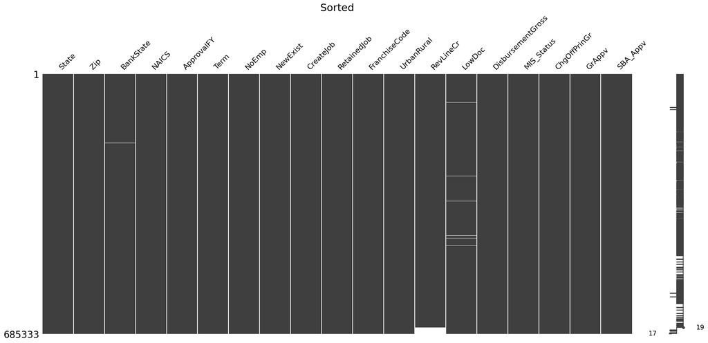

```python
import matplotlib
import matplotlib.pyplot as plt
import warnings
warnings.simplefilter('ignore', DeprecationWarning)
%matplotlib inline

import missingno as mn

mn.matrix(df.sort_values(by=["RevLineCr"]))
plt.title("Sorted",fontsize=22)
plt.show()
```

The only attribute with a non-insignificant amount of missing data is RevLineCr. Because most of it is valid values imputing the missing ones is a viable option.

```python
from operator import concat


df_droped = df.dropna()

vars_to_use = ['Zip', 'NAICS', 'ApprovalFY', 'Term', 'NoEmp', 'NewExist', 'CreateJob', 'RetainedJob', 'FranchiseCode', 'UrbanRural', 'RevLineCr', 'LowDoc', 'DisbursementGross', 'MIS_Status', 'ChgOffPrinGr', 'GrAppv', 'SBA_Appv']
corr1 = df_droped[vars_to_use].corr()['RevLineCr'].abs()
corr1 = corr1.sort_values(ascending=False)

print(corr1.loc[corr1 > 0.25])
```

```
RevLineCr    1.00
Term         0.35
ApprovalFY   0.32
SBA_Appv     0.29
GrAppv       0.27
Name: RevLineCr, dtype: float64
```

In order to create groups that gave RevLineCr the best chance of being imputed reliably I found the attributes which correlated the most with the existing values. I selected the attributes with a correlation over .25 to group by

```python
# discertizing SBA_Appv for the purpose of imputing make the imputed values more evenly distributed
# the discertized version is only temporary
df['SBA_Appv_Disc'] = pd.cut(df['SBA_Appv'], 10, labels=False)
```

In order to use SBA_Appv to group by for imputing I briefly discretized it. I only did this for SBA_Appv and not GrAppv because they convey very similar types of information and I didn't want the groups that were being used for imputing to get too small.

```python
df_grouped = df.groupby(by=['Term', 'ApprovalFY', 'SBA_Appv_Disc'])
# print the average group size
print(round(df_grouped.size().mean(), 4))
func = lambda grp: grp.fillna(grp.median()) # within groups, fill using median (define function to do this)
df_imputed = df_grouped.transform(func) # apply impute and transform the data back

# Extra step: fill any deleted columns from the operation
col_deleted = list( set(df.columns) - set(df_imputed.columns)) # in case the median operation deleted columns
df_imputed[col_deleted] = df[col_deleted]

# drop any rows that still had missing values after grouped imputation
df_imputed.dropna(inplace=True)

# 5. Rearrange the columns
df_imputed = df_imputed[['State', 'Zip', 'BankState', 'NAICS', 'ApprovalFY', 'Term', 'NoEmp', 'NewExist', 'CreateJob', 'RetainedJob', 'FranchiseCode', 'UrbanRural', 'RevLineCr', 'LowDoc', 'DisbursementGross', 'MIS_Status', 'ChgOffPrinGr', 'GrAppv', 'SBA_Appv']]
df_imputed.info()
```

```
57.9465
<class 'pandas.core.frame.DataFrame'>
Int64Index: 684630 entries, 0 to 899161
Data columns (total 19 columns):
 #   Column             Non-Null Count   Dtype
---  ------             --------------   -----
 0   State              684630 non-null  object
 1   Zip                684630 non-null  int64
 2   BankState          684630 non-null  object
 3   NAICS              684630 non-null  int64
 4   ApprovalFY         684630 non-null  int64
 5   Term               684630 non-null  int64
 6   NoEmp              684630 non-null  int64
 7   NewExist           684630 non-null  float64
 8   CreateJob          684630 non-null  int64
 9   RetainedJob        684630 non-null  int64
 10  FranchiseCode      684630 non-null  int64
 11  UrbanRural         684630 non-null  int64
 12  RevLineCr          684630 non-null  float64
 13  LowDoc             684630 non-null  float64
 14  DisbursementGross  684630 non-null  float64
 15  MIS_Status         684630 non-null  float64
 16  ChgOffPrinGr       684630 non-null  float64
 17  GrAppv             684630 non-null  float64
 18  SBA_Appv           684630 non-null  float64
dtypes: float64(8), int64(9), object(2)
memory usage: 104.5+ MB
```

I selected median as the best way to determine the value of RevLineCr in each group because it will return either 1 or 0, keeping RevLineCr a boolean value. The size of each group ended up being around 60 which is big enough for any imputed value to be statistically significant while still letting each group be unique and specific

```
Percent revolving line of credit before and after imputation
Before: 28.82%
After: 28.96%
```

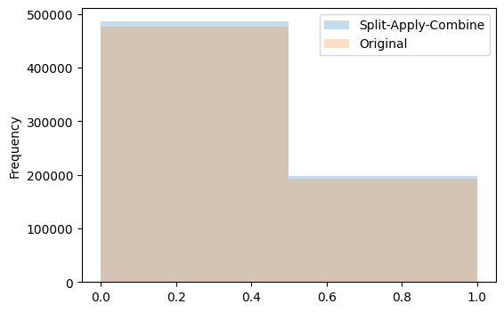

```python
# let's show some very basic plotting to be sure the data looks about the same
# Which imputation did better? The PSlit-Apply-Combine, or  nearest Neighbor Imputer?
# force 4 significant digits
print('Percent revolving line of credit before and after imputation')
print('Before: ' + str(100 * round(df.RevLineCr.sum() / df.RevLineCr.count(), 4)) + '%')
print('After: ' + str(100 * round(df_imputed.RevLineCr.sum() / df_imputed.RevLineCr.count(), 4)) + '%')

plt.figure(figsize=(6, 4))

df_grouped = df.groupby(by='RevLineCr')

bin_num = 2

df_imputed.RevLineCr.plot(kind='hist', alpha=0.25,
                        label="Split-Apply-Combine",
                        bins=bin_num)


df.RevLineCr.plot(kind='hist', alpha=0.25,
                        label="Original",
                        bins=bin_num)

plt.legend()
plt.show()
```

I tried both methods to impute the missing data and settled on split apply combine for two main reasons. First, by trying on small samples of the data this produced better results after carefully picking what features to group by. Secondly, thought the tests I realized that KNN was not a viable strategy for filling in the missing values in a reasonable amount of time with a dataset of this size. Revolving line of credit was missing by far the most data so I used it as a gauge for how well missing values were imputed. The difference between the percent with RevLineCr before and after is just over 1/10 of 1% which I decided was close enough. Over the process of imputing missing values about 700 rows were lost. This is a small enough percent of the data I decided it was negligible.

```python
# now that all NaN values have been imputed or removed, convert all float columns to int
for col in ['NewExist', 'RevLineCr', 'LowDoc', 'MIS_Status']:
    if col in df_imputed:
        df_imputed[col] = df_imputed[col].astype('int')

df_imputed.info()
```

```
<class 'pandas.core.frame.DataFrame'>
Int64Index: 684630 entries, 0 to 899161
Data columns (total 19 columns):
 #   Column             Non-Null Count   Dtype
---  ------             --------------   -----
 0   State              684630 non-null  object
 1   Zip                684630 non-null  int64
 2   BankState          684630 non-null  object
 3   NAICS              684630 non-null  int64
 4   ApprovalFY         684630 non-null  int64
 5   Term               684630 non-null  int64
 6   NoEmp              684630 non-null  int64
 7   NewExist           684630 non-null  int64
 8   CreateJob          684630 non-null  int64
 9   RetainedJob        684630 non-null  int64
 10  FranchiseCode      684630 non-null  int64
 11  UrbanRural         684630 non-null  int64
 12  RevLineCr          684630 non-null  int64
 13  LowDoc             684630 non-null  int64
 14  DisbursementGross  684630 non-null  float64
 15  MIS_Status         684630 non-null  int64
 16  ChgOffPrinGr       684630 non-null  float64
 17  GrAppv             684630 non-null  float64
 18  SBA_Appv           684630 non-null  float64
dtypes: float64(4), int64(13), object(2)
memory usage: 104.5+ MB
```

A significant portion of the information in this dataset is boolean and a good place to start is looking at the distributions of each of these attributes.

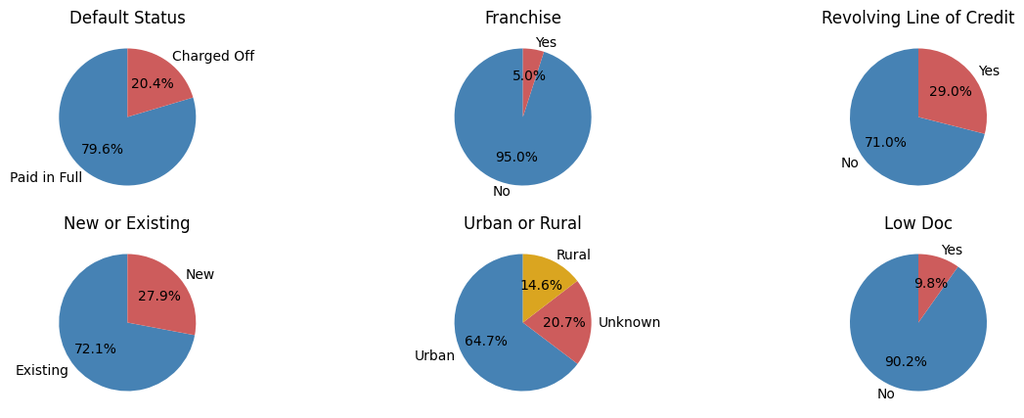

```python
# plot pie charts

fig = plt.figure(figsize=(20, 5))

gs = fig.add_gridspec(2, 4)

axs = []
axs.append( fig.add_subplot(gs[0,1]) )
axs.append( fig.add_subplot(gs[1,1]) )
axs.append( fig.add_subplot(gs[0,2]) )
axs.append( fig.add_subplot(gs[1,2]) )
axs.append( fig.add_subplot(gs[0,3]) )
axs.append( fig.add_subplot(gs[1,3]) )

axs[0].pie(df_imputed.MIS_Status.value_counts(), labels=['Paid in Full', 'Charged Off'], autopct='%1.1f%%', startangle=90, colors=['steelblue', 'indianred'])
axs[1].pie(df_imputed.NewExist.value_counts(), labels=['Existing', 'New'], autopct='%1.1f%%', startangle=90, colors=['steelblue', 'indianred'])
axs[2].pie(df_imputed.FranchiseCode.value_counts(), labels=['No', 'Yes'], autopct='%1.1f%%', startangle=90, colors=['steelblue', 'indianred'])
axs[3].pie(df_imputed.UrbanRural.value_counts(), labels=['Urban', 'Unknown', 'Rural'], autopct='%1.1f%%', startangle=90, colors=['steelblue', 'indianred', 'goldenrod'])
axs[4].pie(df_imputed.RevLineCr.value_counts(), labels=['No', 'Yes'], autopct='%1.1f%%', startangle=90, colors=['steelblue', 'indianred'])
axs[5].pie(df_imputed.LowDoc.value_counts(), labels=['No', 'Yes'], autopct='%1.1f%%', startangle=90, colors=['steelblue', 'indianred'])

axs[0].set_title('Default Status')
axs[1].set_title('New or Existing')
axs[2].set_title('Franchise')
axs[3].set_title('Urban or Rural')
axs[4].set_title('Revolving Line of Credit')
axs[5].set_title('Low Doc')

plt.show()
```

These pie charts break down the loans by their most basic components. While this does not provide any information on what factors effect if a loan is likely to default, it paints a very good picture of what type of businesses apply for small business loans. The average small business applying for a SBA loan is not a franchise, has no revolving line of credit, is an existing business, and is based in an urban area. Breaking down each of these boolean values in relation to if the loan was paid off could give an easy look at an important factor

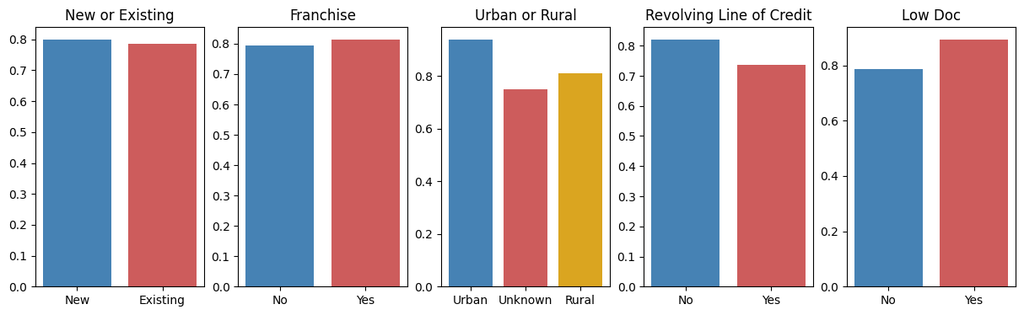

```python
# plot each of the variables against the default rate within each variable

fig = plt.figure(figsize=(15, 4))

gs = fig.add_gridspec(1, 5)


axs = []
for i in range(5):
    axs.append( fig.add_subplot(gs[0, i]) )

for i, col in enumerate(['NewExist', 'FranchiseCode', 'UrbanRural', 'RevLineCr', 'LowDoc']):
    axs[i].bar(df_imputed.groupby(col).MIS_Status.mean().index, df_imputed.groupby(col).MIS_Status.mean(), color=['steelblue', 'indianred', 'goldenrod'])
    axs[i].xaxis.set_ticks([0, 1])

    if col == 'UrbanRural':
        axs[i].xaxis.set_ticks([0, 1, 2])

axs[0].set_title('New or Existing')
axs[1].set_title('Franchise')
axs[2].set_title('Urban or Rural')
axs[3].set_title('Revolving Line of Credit')
axs[4].set_title('Low Doc')

# set the x axis labels as words instead of numbers
axs[0].set_xticklabels(['New', 'Existing'])
axs[1].set_xticklabels(['No', 'Yes'])
axs[2].set_xticklabels(['Urban', 'Unknown', 'Rural'])
axs[3].set_xticklabels(['No', 'Yes'])
axs[4].set_xticklabels(['No', 'Yes'])



plt.show()
```

This provides a good overview of how often a loan is defaulted inside each of these subgroups. Unfortunately this breakdown doesn't reveal a strong correlation between default rate and any of these attributes. A full correlation plot may give a better picture of which attributes have an impact on others .

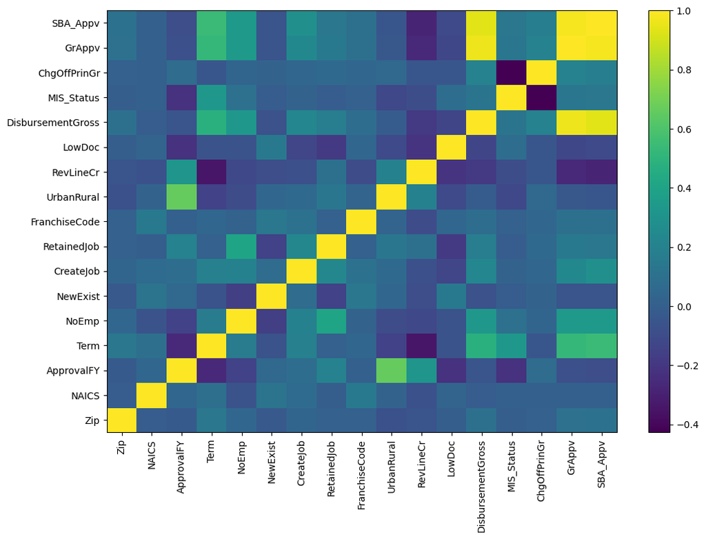

```python
vars_to_use = ['Zip', 'NAICS', 'ApprovalFY', 'Term', 'NoEmp', 'NewExist', 'CreateJob', 'RetainedJob', 'FranchiseCode', 'UrbanRural', 'RevLineCr', 'LowDoc', 'DisbursementGross', 'MIS_Status', 'ChgOffPrinGr', 'GrAppv', 'SBA_Appv']

plt.figure(figsize=(12, 8))

plt.pcolor(df_imputed[vars_to_use].corr()) # do the feature correlation plot

# fill in the indices
plt.yticks(np.arange(0.5, len(vars_to_use), 1), vars_to_use)
plt.xticks(np.arange(0.5, len(vars_to_use), 1), vars_to_use)
plt.colorbar()
# rotate the x-axis labels
plt.xticks(rotation=90)
plt.show()
```

The most obvious correlation is between how much money was approved, how much of it is covered by the government and how much money was actually loaned. There's a dark square at the cross of Term and RevLineCr which makes sense because a longer term loan is more likely to have a plan to pay it off set up, while a very short term loan is more likely to be set up to be paid of all at once. Term is correlated with a number of values, especially the ones related to money. This makes sense as a larger loan is likely to be set up over a longer period of time so each payment is smaller.

## How do factors like year issued, industry, and amount affect the likelihood of default?

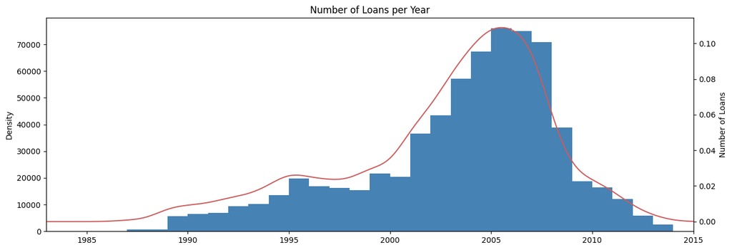

```python
# Loans per year

plt.figure(figsize=(15, 5))

df_imputed.ApprovalFY.hist(bins=30, color='steelblue')
df_imputed.ApprovalFY.plot.kde(bw_method=0.15, secondary_y=True, color='indianred')

# make the plot look nicer
plt.xlabel('Approval Fiscal Year')
plt.ylabel('Number of Loans')
plt.title('Number of Loans per Year')

plt.xlim(df_imputed.ApprovalFY.min() - 1, df_imputed.ApprovalFY.max() + 1)
plt.grid(False)
plt.show()
```

Here the number of loans granted each year is graphed.This graph gives the data a good bearing in the real world. As the amount of loans being taken are strongly tied to how well the economy. Even more so, small business loans are tied to how well the average small business owner can afford to pay back the loan. Most obvious in the graph is the huge dip after the 2007 recession. Small business owners and people looking to start new businesses didn't rebound as quickly as the stock market and thus the amount of loans stayed low.

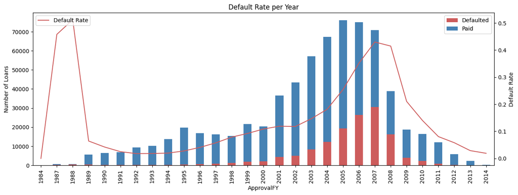

```python
# Loans per year that defaulted

from cProfile import label


plt.rcParams["figure.figsize"] = (15,5)

defaulted = pd.crosstab(df_imputed.ApprovalFY, df_imputed.MIS_Status.astype(bool))
defaulted.plot(kind='bar', stacked=True, color=['indianred', 'steelblue'], grid=False)

plt.legend(['Defaulted', 'Paid'])
plt.ylabel('Number of Loans')

plt.twinx()
plt.plot(np.arange(0, len(defaulted.index), 1), defaulted[False] / (defaulted[False] + defaulted[True]), color='indianred')
plt.ylabel('Default Rate')
plt.legend(['Default Rate'], loc=2)

# make the plot look nicer
plt.xlabel('Approval Fiscal Year')

plt.title('Default Rate per Year')

plt.show()
```

This graph is an expansion of the previous one, further breaking down each year by how many loans were either paid off or defaulted and how that rate changed over time. As expected the rate of defaults climbs slowly as it gets closer to the recession, with a peak at 2007 and a similar rate in 2008. After this the default rate drops down again. It can be assumed the high rate of default in the 1980's are outliers as there is very little data there. A different approach to take is which industries default at higher rates

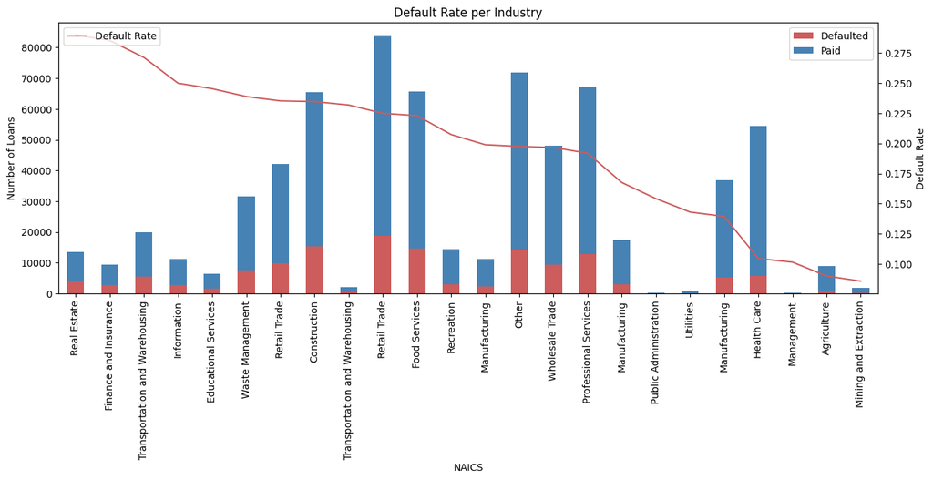

```python
# plot default rate based on industry

from re import S


plt.rcParams["figure.figsize"] = (15,5)

defaulted = pd.crosstab(df_imputed.NAICS, df_imputed.MIS_Status.astype(bool))

# sort the industries by default rate
# get the default rate for each industry
default_rate = defaulted[1] / (defaulted[0] + defaulted[1])
# sort the default rate
default_rate.sort_values(ascending=True, inplace=True, )

defaulted = defaulted.reindex(default_rate.index)
defaulted.plot(kind='bar', stacked=True, color=['indianred', 'steelblue'], grid=False)

plt.legend(labels=['Defaulted', 'Paid'])
plt.ylabel('Number of Loans')

# plot the default rate on a secondary y-axis
plt.twinx()
plt.plot(np.arange(0, len(defaulted.index), 1), defaulted[False] / (defaulted[True] + defaulted[False]), color='indianred')
plt.ylabel('Default Rate')
plt.legend(labels=['Default Rate'], loc='upper left')

# convert the NAICS codes to industry names and set the x-axis labels
naics = [[11, 'Agriculture'], [21, 'Mining and Extraction'], [22, 'Utilities'], [23, 'Construction'], [31, 'Manufacturing'], [32, 'Manufacturing'], [33, 'Manufacturing'], [42, 'Wholesale Trade'], [44, 'Retail Trade'], [45, 'Retail Trade'], [48, 'Transportation and Warehousing'], [49, 'Transportation and Warehousing'], [51, 'Information'], [52, 'Finance and Insurance'], [53, 'Real Estate'], [54, 'Professional Services'], [55, 'Management'], [56, 'Waste Management'], [61, 'Educational Services'], [62, 'Health Care'], [71, 'Recreation'], [72, 'Food Services'], [81, 'Other'], [92, 'Public Administration']]
naics = pd.DataFrame(naics, columns=['NAICS', 'Industry'])
naics = naics.set_index('NAICS')
naics = naics.reindex(defaulted.index)
plt.xticks(np.arange(0, len(defaulted.index), 1), naics.Industry, rotation=90)


# make the plot look nicer
plt.xlabel('NAICS Code')
plt.title('Default Rate per Industry')

plt.show()
```

This graph show how many loans were granted to each industry broken down by if they were paid off or defaulted and sorted by default rate. There is a high amount of variance in default rate by industry. The default rate of an industry is loosely tied to a handful of factors like barriers to entry and how stable income in that industry is. For example, retail trade and construction income are both dependent of consumer demand and it is shown through the higher default rate. Meanwhile industries like health care, agriculture, and mining all have very stable customers and will be more likely to have a income stable enough to consistently pay off a loan. These industries also require significantly more capital and planning, both of which are corralled with a lower default rate.

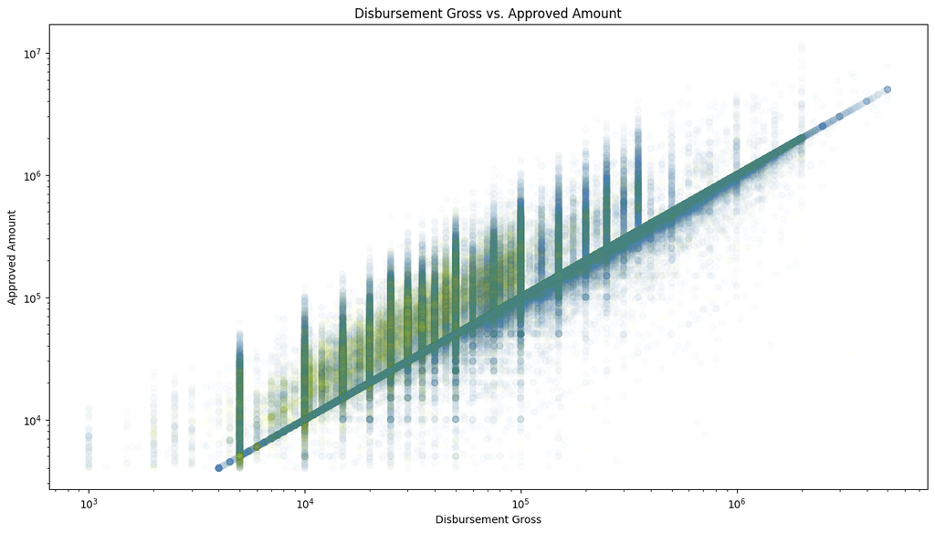

```python
# create a scatter plot of dissbursement gross vs. approved amount
# color the points by default status

plt.figure(figsize=(15, 8))

# set the color based on the default status
colors = ['steelblue' if x == 1 else 'yellow' for x in df_imputed.MIS_Status]

# plot the scatter plot
plt.scatter(df_imputed.GrAppv, df_imputed.DisbursementGross, c=colors, alpha=0.02)

# make the plot look nicer
plt.xscale('log')
plt.yscale('log')
plt.xlabel('Disbursement Gross')
plt.ylabel('Approved Amount')
plt.title('Disbursement Gross vs. Approved Amount')

plt.show()
```

First note the log-log scale and that defaulted loans are now yellow for visibility. This graph primarily shows the very expected correlation between how much the bank approve the loan for and how much much is actually taken. Here the correlation between loan amount and default rate stands out more with the yellow mostly staying in the lower left portion of the graph. This makes sense because a bigger loan is a bigger risk and is better vetted. When looking at these charts it is important to remember that this dataset is only loans that were actually approved. It is possible this trend is even more pronounced when looking at all loan applications and not just accepted ones.

## How does location affect the likelihood of default?

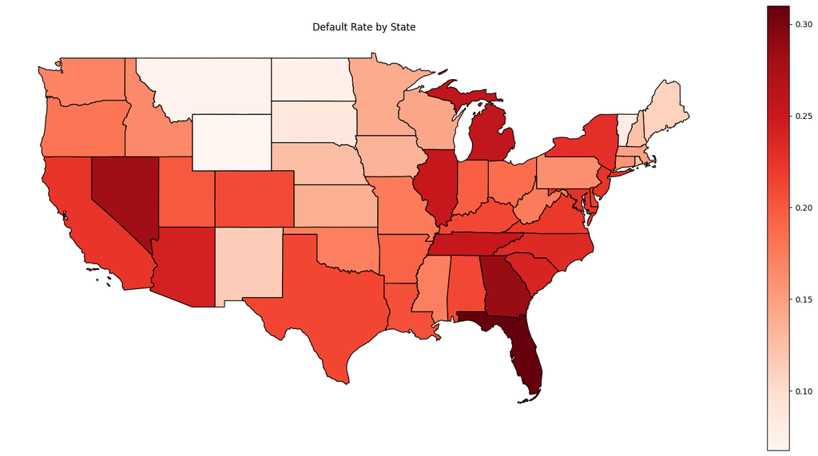

```python
# create a graph of default rate by state
import geopandas as gpd

# read in the shapefile
states = gpd.read_file('../Data/cb_2018_us_state_20m/cb_2018_us_state_20m.shp')

# get rid of states and territories that are not contiguous
states = states[states['STUSPS'].isin(['AK', 'HI', 'PR', 'GU', 'VI', 'AS', 'MP']) == False]

# read in the data
defaulted = 1 - df_imputed.groupby('State').MIS_Status.mean()

# merge the data with the shapefile
merged = states.merge(defaulted, left_on='STUSPS', right_index=True)

plt.rcParams["figure.figsize"] = (20,10)

# plot the data
merged.plot(column='MIS_Status', cmap='Reds', edgecolor='black', legend=True)

# make the plot look nicer
plt.axis('off')
plt.title('Default Rate by State')

plt.show()
```

In this map each state is colored by how likely a business from that state is to default on their loan. In general the more populous states tend to have higher default rates, with Florida being particularly high. Each state has a local economy that greatly effects how well a business there will perform. A reflection of the industry data can be seen seen here as some states commonly attract more stable industries like agriculture. This leads to them having a lower default rate.

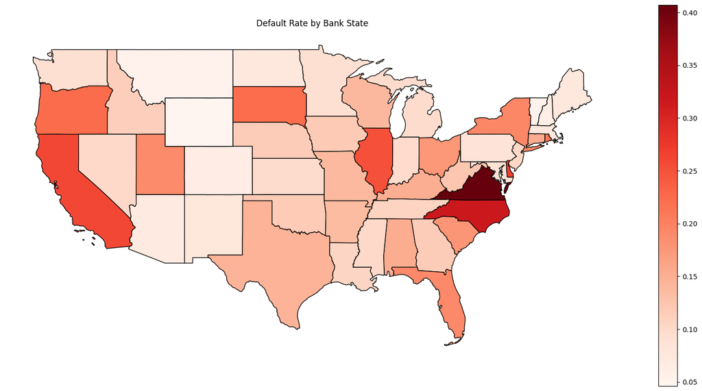

```python
# read in the data
defaulted = 1 - df_imputed.groupby('BankState').MIS_Status.mean()

# merge the data with the shapefile
merged = states.merge(defaulted, left_on='STUSPS', right_index=True)

plt.rcParams["figure.figsize"] = (20,10)

# plot the data
merged.plot(column='MIS_Status', cmap='Reds', edgecolor='black', legend=True)

# make the plot look nicer
plt.axis('off')
plt.title('Default Rate by Bank State')

plt.show()
```

It's hard to infer much from seeing that the states that have the highest default rate for small businesses are different than the states that have the highest default rate for banks. One thing this makes clear is that a good portion of the businesses that default are not applying for loans in their home state. This can easily be verified by plotting it separately

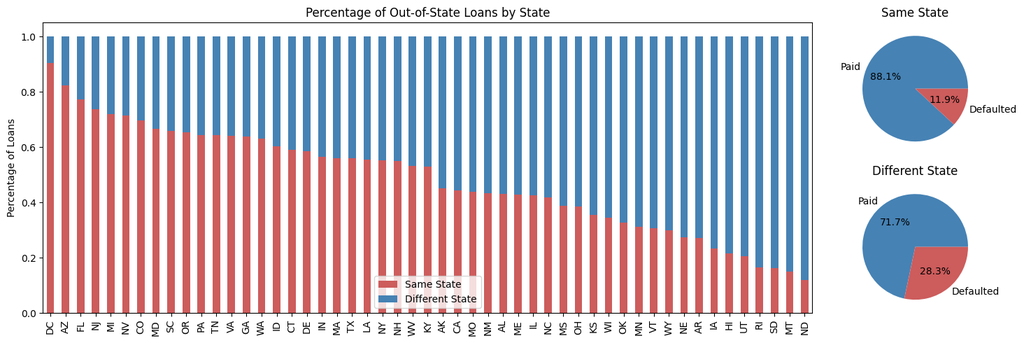

```python
from cProfile import label


plt.rcParams["figure.figsize"] = (15,5)

other_state = df_imputed[df_imputed.State != df_imputed.BankState]
same_state = df_imputed[df_imputed.State == df_imputed.BankState]

traveled = pd.crosstab(df_imputed.State, df_imputed.State == df_imputed.BankState, normalize='index')

# sort the states by the number of loans from a different state
traveled = traveled.sort_values(by=False, ascending=False)

fig = plt.figure()
gs = fig.add_gridspec(2, 5)
axs = []
axs.append( fig.add_subplot(gs[:,0:4]) ) # large subplot (2 rows, 2 columns)
axs.append( fig.add_subplot(gs[0,4]) )   # small subplot (1st row, 3rd column)
axs.append( fig.add_subplot(gs[1,4]) )   # small subplot (2nd row, 3rd column)

# plot the data as a 100% stacked bar chart
traveled.plot(kind='bar', stacked=True, color=['indianred', 'steelblue'], grid=False, ax=axs[0])

# plot the default rate for loans from the same state as a pie chart
same_state.MIS_Status.value_counts().plot(kind='pie', autopct='%1.1f%%', colors=['steelblue', 'indianred'], ax=axs[1], labels=['Paid', 'Defaulted'])
# plot the default rate for loans from a different state as a pie chart
other_state.MIS_Status.value_counts().plot(kind='pie', autopct='%1.1f%%', colors=['steelblue', 'indianred'], ax=axs[2], labels=['Paid', 'Defaulted'])

# make the plot look nicer
axs[0].legend(['Same State', 'Different State'])
axs[0].set_xlabel('')
axs[0].set_ylabel('Percentage of Loans')
axs[0].set_title('Percentage of Out-of-State Loans by State')
axs[1].set_ylabel('')
axs[1].set_title('Same State')
axs[2].set_ylabel('')
axs[2].set_title('Different State')

plt.tight_layout()
plt.show()
```

## How does loan term affect the likelihood of default?

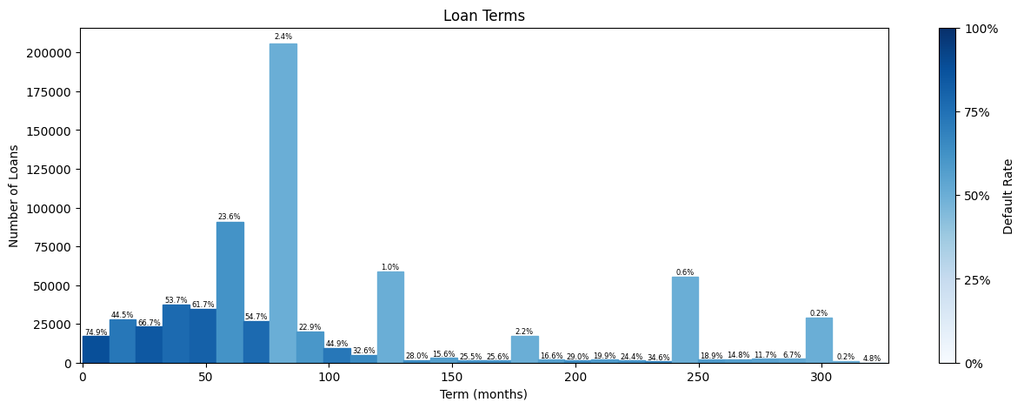

```python
# hist of loan term on ax
plt.figure(figsize=(15, 5))

ax = df_imputed.Term.hist(bins=30, color='steelblue')

default_rate_by_bin = []

# add value labels on top of bars of default rate
for p in ax.patches:
    # get the loans that match the bin
    loans = df_imputed[(df_imputed.Term >= p.get_x()) & (df_imputed.Term < p.get_x() + p.get_width())]
    # get the default rate
    default_rate = 1 - loans.MIS_Status.mean()
    # add the value label small
    ax.annotate('{:.1f}%'.format(default_rate * 100), (p.get_x() + p.get_width() / 2, p.get_height() * 1.01), ha='center', va='bottom', size=6)
    # add the default rate to the list
    default_rate_by_bin.append(default_rate)

num_colors = 30
# map from blue to dark blue log scale
cm = plt.get_cmap('Blues')
# get only the dark half of the color map
blues = cm(np.linspace(0.5, 1, num_colors))
# evenly space the blues over the number of bins
colors = blues[np.linspace(0, num_colors - 1, len(ax.patches)).astype(int)]

# sort each bar by its default rate and color it accordingly
for i, bar in enumerate(plt.gca().patches):
    bar.set_color(colors[int(default_rate_by_bin[i] * num_colors)])

# add a legend for the colors as a colorbar
sm = plt.cm.ScalarMappable(cmap=cm, norm=plt.Normalize(vmin=0, vmax=1))
sm._A = []
cbar = plt.colorbar(sm, ticks=[0, 0.25, 0.5, 0.75, 1], ax=ax)
cbar.ax.set_yticklabels(['0%', '25%', '50%', '75%', '100%'])
cbar.set_label('Default Rate')

# make the plot look nicer
plt.title('Loan Terms')
plt.xlabel('Term (months)')
plt.ylabel('Number of Loans')

plt.xlim(df_imputed['Term'].min() - 1, df_imputed['Term'].max() + 1)
plt.grid(False)
plt.show()
```

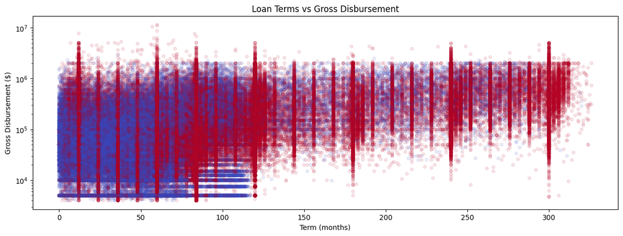

```python
# plot term vs gross disbursement
plt.figure(figsize=(15, 5))

# plot the data
df_imputed.plot.scatter(x='Term', y='DisbursementGross', c='MIS_Status', cmap='coolwarm', colorbar=False, alpha=0.1)

# make the plot look nicer
plt.yscale('log')
plt.title('Loan Terms vs Gross Disbursement')
plt.xlabel('Term (months)')
plt.ylabel('Gross Disbursement ($)')
plt.grid(False)
plt.show()
```

Because both loan term and loan amount have been shown to correlate with default rate, it would make sense for them to have a similar relation to each other. All of these relationships can be seen in the above plot. This plot also better shows the most common loan terms, all of which have a much lower default rate as seen by the striking red lines. This reiterates the idea that a better planned business would be more likely to pay off their loan as more planning would likely settle on a loan term that is well established.

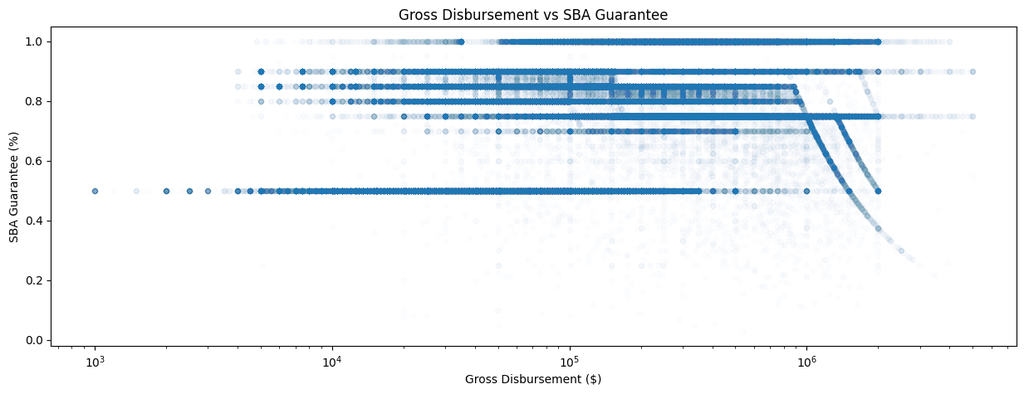

```python
# plot what percent of a loan is guaranteed by the SBA
plt.figure(figsize=(15, 5))

# percent guaranteed = SBA_Appv / GrAppv
df_imputed['PercentGuaranteed'] = df_imputed.SBA_Appv / df_imputed.GrAppv

# plot the data
df_imputed.plot.scatter(x='GrAppv', y='PercentGuaranteed', alpha=0.01)

# make the plot look nicer
plt.xscale('log')
plt.title('Gross Disbursement vs SBA Guarantee')
plt.xlabel('Gross Disbursement ($)')
plt.ylabel('SBA Guarantee (%)')
plt.grid(False)
plt.show()
```

An important part of SBA loans is that a large part of the risk is mitigated by the government by covering a percent of the loan to the bank even if the business defaults. This graph makes sheds some light on how much is covered. Most obviously, the percent covered tends to be a round number between 50% and 100%, producing the clear lines on the chart. Less obviously the curved vertical lines are produced by the log scale on the x axis and a max amount to be covered. This is reflected in the information from the SBA website shown below. "For most 7(a) loan programs, the SBA can guarantee up to 85 percent of loans of $150,000 or less, and up to 75 percent of loans above $150,000. However, SBA Express loans carry a maximum of 50 percent guaranty and Export Express loans carry a maximum 90 percent guaranty. The Export Working Capital loan program and International Trade loans carry a maximum of 90 percent guaranty, up to a guaranteed amount of $4.5 million."